SYSTEMATIC REVIEW

published: 22 March 2018

doi: 10.3389/fnins.2018.00189

Frontiers in Neuroscience | www.frontiersin.org

1

March 2018 | Volume 12 | Article 189

Edited by:

Francisco Lopez-Munoz,

Universidad Camilo José Cela, Spain

Reviewed by:

Vikas Mishra,

Babasaheb Bhimrao Ambedkar

University, India

Vincenzo Marra,

University of Leicester,

United Kingdom

*Correspondence:

Patrícia Pereira

patriciapereira@ufrgs.br

Specialty section:

This article was submitted to

Neuropharmacology,

a section of the journal

Frontiers in Neuroscience

Received: 14 December 2017

Accepted: 08 March 2018

Published: 22 March 2018

Citation:

Regner GG, Pereira P, Leffa DT, de

Oliveira C, Vercelino R, Fregni F and

Torres ILS (2018) Preclinical to Clinical

Translation of Studies of Transcranial

Direct-Current Stimulation in the

Treatment of Epilepsy: A Systematic

Review. Front. Neurosci. 12:189.

doi: 10.3389/fnins.2018.00189

Preclinical to Clinical Translation of

Studies of Transcranial

Direct-Current Stimulation in the

Treatment of Epilepsy: A Systematic

Review

Gabriela G. Regner <sup>1,2,3</sup>, Patrícia Pereira <sup>1,3</sup>*, Douglas T. Leffa <sup>2,4</sup>, Carla de Oliveira <sup>2,4</sup>,

Rafael Vercelino <sup>2,5</sup>, Felipe Fregni <sup>6</sup>and Iraci L. S. Torres <sup>2,3,4</sup>

1 Laboratory of Neuropharmacology and Preclinical Toxicology, Institute of Basic Health Sciences, Universidade Federal do

Rio Grande do Sul, Porto Alegre, Brazil, <sup>2</sup>Laboratory of Pain Pharmacology and Neuromodulation, Preclinical Studies -

Pharmacology Department, Institute of Basic Health Sciences, Universidade Federal do Rio Grande do Sul, Porto Alegre,

Brazil, <sup>3</sup>Postgraduate Program in Biological Sciences, Pharmacology and Therapeutics, Institute of Basic Health Sciences,

Universidade Federal Rio Grande do Sul, Porto Alegre, Brazil, <sup>4</sup>Postgraduate Program in Medical Sciences, School of

Medicine Universidade Federal Rio Grande do Sul, Porto Alegre, Brazil, <sup>5</sup>Centro Universitário FADERGS, Health and Wellness

School Laureate International Universities, Porto Alegre, Brazil, <sup>6</sup>Laboratory of Neuromodulation, Department of Physical

Medicine & Rehabilitation, Spaulding Rehabilitation Hospital and Massachusetts General Hospital, Harvard University,

Boston, MA, United States

Epilepsy is a chronic brain syndrome characterized by recurrent seizures resulting from

excessive neuronal discharges. Despite the development of various new antiepileptic

drugs, many patients are refractory to treatment and report side effects. Non-invasive

methods of brain stimulation, such as transcranial direct current stimulation (tDCS),

have been tested as alternative approaches to directly modulate the excitability of

epileptogenic neural circuits. Although some pilot and initial clinical studies have shown

positive results, there is still uncertainty regarding the next steps of investigation in

this ﬁeld. Therefore, we reviewed preclinical and clinical studies using the following

framework: (1) preclinical studies that have been successfully translated to clinical

studies, (2) preclinical studies that have failed to be translated to clinical studies, and

(3) clinical ﬁndings that were not previously tested in preclinical studies. We searched

PubMed, Web of Science, Embase, and SciELO (2002–2017) using the keywords

“tDCS,” “epilepsy,” “clinical trials,” and “animal models.” Our initial search resulted in 64

articles. After applying inclusion and exclusion criteria, we screened 17 full-text articles

to extract ﬁndings about the efﬁcacy of tDCS, with respect to the therapeutic framework

used and the resulting reduction in seizures and epileptiform patterns. We found that

few preclinical ﬁndings have been translated into clinical research (number of sessions

and effects on seizure frequency) and that most ﬁndings have not been tested clinically

(effects of tDCS on status epilepticus and absence epilepsy, neuroprotective effects in

the hippocampus, and combined use with speciﬁc medications). Finally, considering that

clinical studies on tDCS have been conducted for several epileptic syndromes, most

were not previously tested in preclinical studies (Rasmussen’s encephalitis, drug resistant

epilepsy, and hippocampal sclerosis-induced epilepsy). Overall, most studies report

positive ﬁndings. However, it is important to underscore that a successful preclinical

study may not indicate success in a clinical study, considering the differences highlighted

herein. Although most studies report signiﬁcant ﬁndings, there are still important insights

from preclinical work that must be tested clinically. Understanding these factors may

improve the evidence for the potential use of this technique as a clinical tool in the

treatment of epilepsy.

Keywords: animal models, clinical trials, epilepsy, non-invasive brain stimulation, transcranial direct current

stimulation

INTRODUCTION

Techniques involving stimulation of the central nervous system

have been extensively studied in recent years. These techniques

have been shown to improve symptoms in a range of neurological

disorders. Both invasive and non-invasive brain stimulation

techniques have been described. Non-invasive techniques can

be divided into transcranial magnetic stimulation (TMS),

transcranial alternating current stimulation, and transcranial

direct current stimulation (tDCS) (Woods et al., 2016).

tDCS relies on the modiﬁcation of the neuronal resting

membrane potential to induce changes in cortical excitability.

This technique consists on applying a weak, direct, constant, and

low intensity electric current over the scalp using two electrodes:

an anode and a cathode (Gomez Palacio Schjetnan et al., 2013).

The electrodes are arranged in diﬀerent assemblies, creating

a ﬂow of low-level continuous electrical current targeting

a speciﬁc region of the cerebral cortex. Anodal stimulation

induces depolarization of the neuronal membrane, and therefore

facilitates neuronal ﬁring. In contrast, cathodal stimulation has

the opposite eﬀect, hyperpolarizing the neuronal membrane

(**Figure 1**; Jackson et al., 2016). tDCS is applied at intensities

ranging from 0.5–2 mA across saline-soaked electrodes placed on

the human or animal scalp (**Figure 2**) [from author].

tDCS has been shown to improve symptoms in patients with

depression, stroke, focal dystonia, migraine, chronic pain, and

epilepsy (Liebetanz et al., 2006a). Epilepsy represents a chronic

brain syndrome of diverse etiology, characterized by recurrent

seizures resulting from excessive neuronal discharge (Chindo

et al., 2014). This syndrome aﬀects ∼0.5–1% of the world’s

population (Dhir et al., 2005), and is associated with a variety

of clinical symptoms such as impaired consciousness, movement

and sensation (Chindo et al., 2014). Epileptical discharges are

generated in response to a loss of balance between excitatory and

inhibitory connections, resulting in tonic depolarization of brain

circuits (McCormick and Contreras, 2001). The pathophysiology

of epilepsy includes hyperactivity of excitatory glutamatergic

transmission, and a deﬁcit of inhibitory signaling, mainly

resulting from insuﬃcient neurotransmission mediated by γ-

aminobutyric acid A receptors (GABAAR) (Lason et al., 2013).

Despite the diversity of new antiepileptic drugs, a large

proportion of individuals suﬀering from epilepsy is refractory

to pharmacology treatment (Loscher, 2002), and/or reports side

eﬀects which hinder the use of drugs. Epidemiological data

indicate that 20–40% of patients with newly diagnosed epilepsy

become refractory to treatment (Loscher and Schmidt, 2004;

French, 2007). For this reason, there is a continuous search for

new therapeutic strategies, from which tDCS has emerged as

a possible alternative. In this study, we aimed to summarize

the evidence concerning the eﬀects of tDCS in epilepsy in both

clinical and preclinical studies. We used a framework to provide

insight into the translation rate of preclinical into clinical studies.

In addition, we attempted to determine important areas for

clinical testing, to verify if these results are complementary, and

to identify possible limitations of these studies.

METHODS

Search Strategy

This systematic review was based on a literature search using

PubMed, Web of Science, Embase and SciELO. The keyword

“tDCS” was used in combination with other keywords such

as “epilepsy,” “clinical trials,” and “animal models.” The term

“AND” was used in each combination (**Figure 3**). In addition, the

reference sections of the studies that met our inclusion criteria

were manually screened for relevant publications.

Inclusion and Exclusion Criteria

Studies had to meet the following criteria: (1) publication in

English between 2002 and 2017, (2) report original research,

and (3) report case reports. Exclusion criterion were: (1) lack

of original data (e.g. review articles, editorial material, articles

reporting duplicate data); (2) articles addressing only eﬀects of

other brain stimulation techniques, such as alternating electrical

current stimulation, or TMS.

Data Extraction and Outcomes

Two investigators (GGR and CO) extracted data from the full

articles independently. Any disagreements were resolved by a

third investigator (PP). However, we summarized the results

in a narrative format. The primary outcome of our study was

seizure suppression (SS). Relevant articles reporting the outcome

of interest were identiﬁed, and standardized tables were utilized

to extract the following variables: experiment, total sessions,

interval between sessions, number of individuals (N), montage,

contact area of electrodes, sham group and results/insights. The

primary author collected the name of the authors, titles and study

design. When further information about the study was needed,

the authors were contacted by email.

Regner et al.

Translating tDCS Studies in Epilepsy

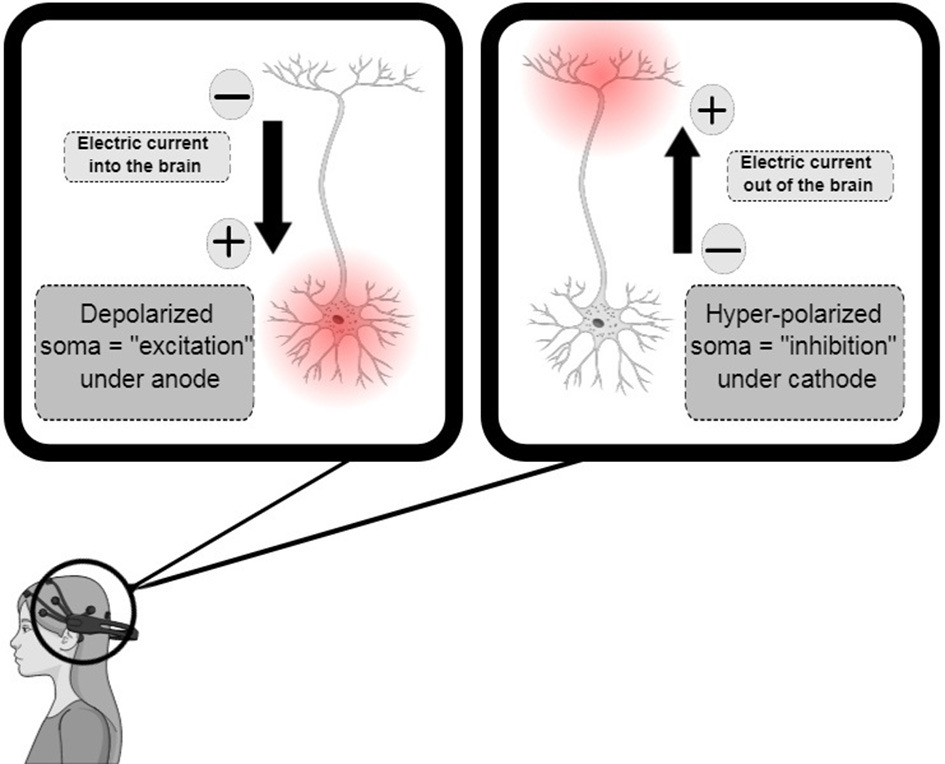

FIGURE 1 | Transcranial direct-current stimulation design, demonstrating

anodal, and cathodal stimuli with consequent depolarization (increase in

excitability) and hyperpolarization (decrease in excitability), respectively.

Adapted from Jackson et al. (2016).

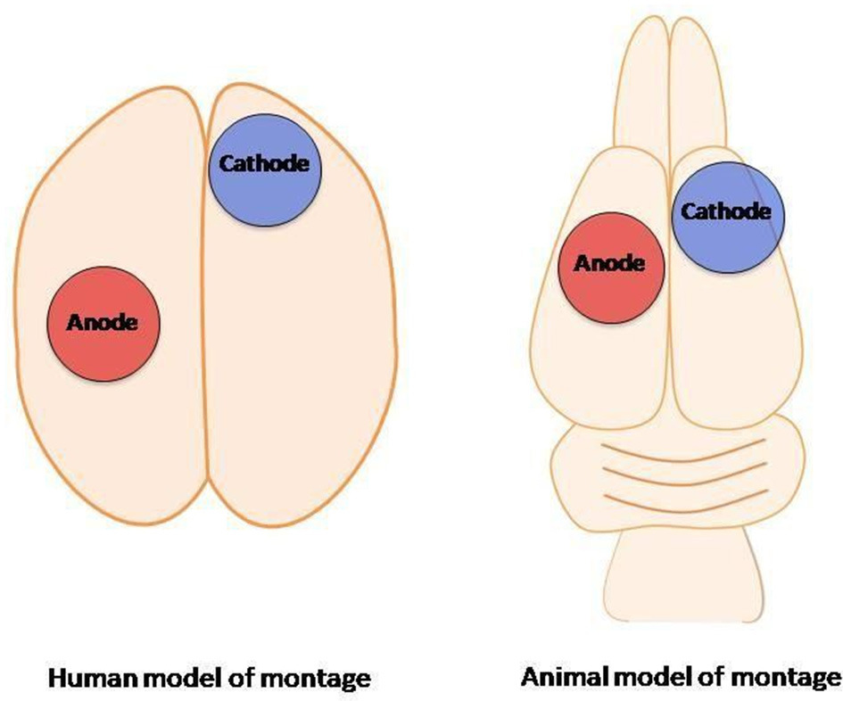

FIGURE 2 | Transcranial direct-current stimulation: human montage vs.

transcranial direct-current stimulation animal model (from author).

Risk of Bias Assessment

Risk of bias was assessed by two reviewers (GGR and CO), for

each included preclinical study, using SYRCLE’s Risk of Bias

tool for animal studies (Hooijmans et al., 2014). We extracted

study characteristics related to construct and external validity

(Henderson et al., 2013). For construct validity, we included

sex, species and strain, type of epilepsy model, total treatment

sessions and the interval between them, and the use of any

other intervention. For clinical studies, we ranked each of

the following as having a high, low, or unclear risk of bias

when included allocation concealment, blinding of participants,

personnel and outcome assessors, incomplete outcome data, and

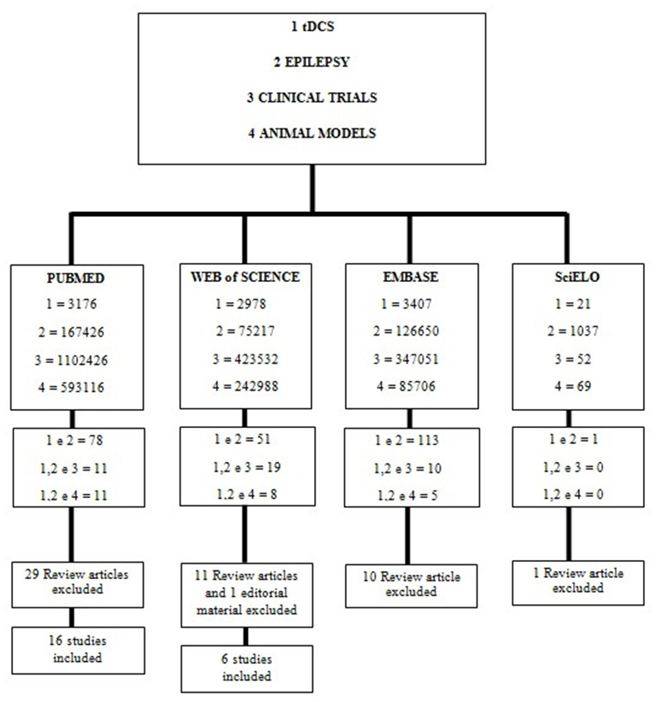

FIGURE 3 | Flowchart of the query on transcranial direct-current stimulation in

major databases.

selective outcome reporting (Higgins and Green, 2011). Since

the primary outcome included only the tDCS eﬀectiveness, not

harmful eﬀects, results may be biased.

Framework of Translation From Preclinical

Studies to Clinical Studies

In order to analyze the results for this review, we used a

framework to understand whether preclinical ﬁndings were

translated into clinical studies, and whether or not this

translational research conﬁrmed preclinical ﬁndings. Therefore,

we created three main categories: (1) preclinical studies that have

been successfully translated in clinical studies, (2) preclinical

studies that have failed to translate in clinical studies, (3) clinical

ﬁndings that were not tested previously in preclinical studies.

RESULTS

The ﬁnal search identiﬁed 64 studies. After applying the inclusion

and exclusion criteria, we included 17 articles with diﬀerent

types of designs (5 preclinical/12 clinical) for full-text analysis.

We screened the articles according to the main outcome, the

suppression of seizures, and summarized the results separately

for basic (**Table 1**) and clinical (**Table 2**) research. Interestingly,

framework discussed above.

From **Tables 1**,**2**, we observed that most clinical studies

showed signiﬁcant results with respect to epileptiform activity,

though only 11 studies (91.67%) had positive results in clinical

Regner et al.

Translating tDCS Studies in Epilepsy

TABLE 1 | Summary of tDCS and animal models of epilepsy.

Author

(year)

Title

Type of

article

Experiment

Total

sessions

Interval

between

sessions

N

Montage

Contact

area of

electrodes

Sham

group

Results/insights

Liebetanz

et al., 2006b

Anticonvulsant

effects of

tDCS in the

rat cortical

ramp model

of focal

epilepsy

Original

article

(1) c-tDCS (100 µA) for 30 and 60 min,

anodal tDCS (100 µA) for 60 min, and

60 min of c-tDCS (n = 7)

(2) c-tDCS (200 µA) for 15 and 30 min,

anodal tDCS (200 µA) for 30 min, and

c-tDCS for 30 min (n = 8)

(1) 4

sessions-

−210 min

(2) 4

sessions-

−105 min

1 week

65 male

Wistar

rats

2 mm left and 2 mm anterior

to the bregma

3.5 mm3

No

The anticonvulsive effect induced by

c-tDCS depends on stimulation duration

and current strength and may be

associated with the induction of alterations

of cortical excitability that outlast the

actual stimulation.

Kamida et al.,

2011

tDCS

decreases

convulsions

and spatial

memory

deﬁcits

following SE

in immature

rats

Original

article

Daily c-tDCS, for 30 min with an intensity

of 200 µA, for 2 weeks (n = 6)

14

sessions-

−420 min

24 h

18 male

Wistar

rats

1.5 mm to the right and

2 mm anterior to the bregma

3.5 mm3

No

Reduction of SE-induced hippocampal cell

loss, supragranular and CA3 mossy ﬁber

sprouting, and convulsions (reduction of

21%) in immature rats. tDCS treatment

also rescued cognitive impairment

following SE.

Kamida et al.,

2013

c-tDCS

affects SZs

and cognition

in fully

amygdala-

kindled

rats

Original

article

Daily 30 min c-tDCS with an intensity of

200 µA for 1 week (n = 6)

7

sessions-

−210 min

24 h

18 male

Wistar

rats

1.5 mm to the right and

2 mm anterior to the bregma

3.5 mm3

Yes

c-tDCS treatment improved the SZ stage

and decreased ADD together with

elevated ADT 1 day after the last tDCS

session. The treatment also yielded

signiﬁcant improvement in the

performance of WMT. c-tDCS has

anticonvulsive after-effects that last at least

1 day in the amygdale-kindled rats and

positively affects cognitive performance.

Zobeiri and

van Luijtelaar,

2013

Non-invasive

tDCS in a

genetic

absence

model

Original

article

(1) 4 series of 15 min cathodal and anodal

stimulation of 100 µA with an interval of

105 min in counter balanced order (n = 10)

(2) 4 sessions of 15 min of cathodal

stimulation of 100 µA (n = 8)

(3) Similar protocol to (2), except that

intensity was 150 µA (n = 8)

(1), (2)

4and (3) =

sessions-

−60 min

105 min

in all

protocols

26 male

WAG/Rij

rats

Stimulation electrodes were

placed on both hemispheres

considering that the foci are

bilateral. The two stimulation

electrodes were ﬁxed onto

the cranium above the right

and left somatosensory

cortices (V/L −4.6 and V/L

+4/6, respectively) and the

reference electrode onto the

cranium above the frontal

cortex with no speciﬁc

coordinate

3.5 mm3

No

c-tDCS reduced the number of SWDs

during stimulation and affected the mean

duration after stimulation both in an

intensity-dependent manner. Behavior was

changed after the highest stimulation

intensity.

Dhamne

et al., 2015

Acute SZ

suppression

by tDCS in

rats

Original

article

(1) Rats received tDCS sham tDCS,

c-tDCS 1,000 µA, or c-tDCS 100 µA; for

20 min (n = 23, 22, 20, respectively)

(2) 2 animal groups received a

subtherapeutic lorazepam dose and then

verum (c-tDCS 1000 µA) (n = 11) or sham

tDCS (n = 10).

(1) and

(2) = 1

session-

−20 min

114 male

Long

Evans

rats

Disk (active), and sponge

(reference) electrodes were

secured to the rat’s scalp

and torso, respectively.

Yes

Cathodal 1 mA tDCS reduced EEG spike

bursts, and suppressed clinical SZs in

combination with lorazepam and was

more effective in SZ suppression and

improved the clinical SZ outcomes

compared to either tDCS or lorazepam

alone.

ADD: After-discharge duration; ADT: After-discharge threshold; c-tDCS: Cathodal transcranial direct-current stimulation; EEG: Electroencephalogram; SE: Status epilepticus; SWDs: Spike and slow-wave discharges; SZ: Seizure; tDCS:

Transcranial direct-current stimulation; WMT: Water maze test.

Regner et al.

Translating tDCS Studies in Epilepsy

TABLE 2 | Summary of tDCS and epilepsy clinical trials.

Author (year)

Title

Type of article

Experiment

Total

sessions

Interval

between

sessions

N

Montage

Contact

area of

electrodes

Sham

group

Results/insights

Fregni et al.,

2006

A controlled clinical trial

of cathodal DC

polarization in patients

with refractory epilepsy

A randomized,

sham-controlled clinical trial

Single session of 1 mA

c-tDCS for 20 min

1 session

– 20 min

19

subjects

(11 male

and 8

female)

Cathodal electrode has been

placed over the

epileptogenic focus and the

anode electrode over a silent

area (without epileptogenic

activity)

35 cm2

Yes

(10

active

and 9

sham)

c-tDCS reduced EDs

(64.3%) and SZ frequency

(44%) when compared with

sham group (5.8%) and

(11.1%) respectively.

Yook et al.,

2011

Suppression of SZs by

c-tDCS in an epileptic

patient-a case report

Case report

5 days a week, during 2

weeks. Repeating

procedure after 2

month, 20 min (2 mA for

20 min)

10

sessions-

−200 min

24 h

1 subject

(female)

Cathode electrode applied

on midpoint between P4 and

T4 area and anode electrode

on left supraorbital area.

25 cm2

During the ﬁrst 2 months

after treatment; the patient

had only six SZs, with an

evident clinical improvement,

after the second intervention

the patient had just one SZ

attack over 2 months.

San-Juan

et al., 2011

tDCS in adolescent and

adult Rasmussen’s

encephalitis

Case report

60 min in 4 sessions (on

days 0, 7, 30, and 60)

1 mA for patient (1) and

2 mA for patient (2)

4

sessions-

−240 min

7, 23 and 30

days

respectively

2

subjects

(male)

(1) (C3

[–/cathode]/contralateral

supraorbital area [+/anode])

(2) (F2 [–/cathode]/F8

[+/anode])

Subdermal

needle

12 mm in

length and

0.4 mm in

diameter

One patient was SZ free and

another patient showed

50% SZ frequency reduction

within 6 month of follow-up.

Faria et al.,

2012

Feasibility of focal

transcranial DC

polarization with

simultaneous EEG

recording: preliminary

assessment in healthy

subjects and human

epilepsy

Cross-over controlled trial

with 15 healthy subjects and

preliminary effects of its use,

testing repeated tDCS

sessions, in two patients

with drug-refractory

Continuous Spike-Wave

Discharges During Slow

Sleep (CSWS)

Once weekly, to 3

afternoon sessions of

30 min each. Current

was ramped in steps of

0.1 mA, with a duration

of 10 s each, until the

target current of 1 mA.

3

sessions-

−90 min

7 days

2

subjects

(male)

Based in 10–10 International

system positions in a cap

(mostly C5-C6)

35 cm2

A large reduction after

c-tDCS was found in IEDs in

C5 (mean 32.1%) during and

after tDCS (10 min).

Auvichayapat

et al., 2013

tDCS for treatment of

refractory childhood

focal epilepsy

Controlled study

Single session of 1 mA

c-tDCS for 20 min

1

session-

−20 min

36

subjects

(26 male

and 10

female)

Cathodal electrode was

placed over the

epileptogenic focus,

centered on the electrode

with the international 10-20

EEG electrode placement

system location where

spikes of sharp waves were

greatest in amplitude, and

the anodal electrode was

placed over the contralateral

shoulder area.

35 cm2

Yes

(27

active

and 9

sham)

c-tDCS can suppress EDs

frequency in 57.6% for 48 h,

but the effect of a single

session on EEG

abnormalities was not

sustained for 4 weeks. A

statistical reduction in the

frequency of SZs was found

(4.8%) in the post-hoc

analysis.

Assenza

et al., 2014

Efﬁcacy of c-tDCS in

drug-resistant epilepsy:

a proof of principle

Single blind and

sham-controlled study

Two sessions, (1 sham

and 1 real on the 8th

and 22th days) 1 mA

intensity applied for

9 min

1 real

session-

−9 min

2

subjects

(male)

Cathodal electrode has been

placed over the

epileptogenic focus and the

anode electrode over the

contralateral homologous

region

12.25 cm2

Patients showed a

consistent reduction of the

SZ frequency: about 70% for

Patient 1 and about 50% for

Patient 2.

(Continued)

Regner et al.

Translating tDCS Studies in Epilepsy

TABLE 2 | Continued

Author (year)

Title

Type of article

Experiment

Total

sessions

Interval

between

sessions

N

Montage

Contact

area of

electrodes

Sham

group

Results/insights

Tekturk et al.,

2016b

The effect of

transcranial direct

current stimulation on

SZ frequency of

patients with mesial

temporal lobe epilepsy

with hippocampal

sclerosis

A randomized cross-over

study

2 mA for 30 min on 3

consecutive days

3 real

sessions-

−90 min

24 h

12

subjects

(6 male/6

female)

Active electrode placed over

the pathologically affected

HS side (temporal region,

either T3 or T4 electrode

place), which was

determined by both

concordant cranial MRI and

ictal or interictal EEG

ﬁndings, depending on the

availability of the seizure

records, and reference

electrode over the

contralateral supraorbital

region

35 cm2

Ten patients showed a more

than 50% decrease in their

SZ frequency after c-tDCS.

Six patients were SZ-free in

the post c-tDCS period of 1

month.

Auvichayapat

et al., 2016

Transcranial Direct

Current Stimulation for

Treatment of Childhood

Pharmacoresistant

Lennox-Gastaut

Syndrome: a Pilot Study

A randomized, double-blind

controlled trial

Five consecutive days

of 2 mA c-tDCS for

20 min

5

sessions-

−100 min

24 h

22

subjects

(14 male

and 8

female)

The stimulation site over the

left M1, located based on

the international

electroencephalography

(EEG) 10/20 electrode

placement system. The

reference electrode was

placed over the right

shoulder area.

35 cm2

Yes

(15

active

and 7

sham)

Participants assigned to the

active tDCS condition

reported signiﬁcantly more

pre- to post-treatment

reductions in SZ frequency

and epileptic discharges that

were sustained for 3 weeks

after treatment.

Tekturk et al.,

2016a

Transcranial direct

current stimulation

improves SZ control in

patients with

Rasmussen’s

encephalitis

Descriptive study of a small

case series

First cathodal, then

anodal (2 mA for 30 min

on 3 consecutive days

for non-sham

stimulations), and ﬁnally

sham stimulation with

2-month intervals

3

sessions

– 90 min

24 h

5

subjects

(2 male/3

female)

Active electrodes placed

over the mostly affected area

and reference electrodes

over the contralateral

mastoid region

35 cm2

After cathodal stimulation, all

but one patient had a greater

than 50% decrease in SZs

frequency. Two patients who

received modulated c-tDCS

had better results. The

longest positive effect lasted

for 1 month.

Zoghi et al.,

2016

The effects of cathodal

transcranial direct

current stimulation in a

patient with

drug-resistant temporal

lobe epilepsy (case

study)

Case report

2 sessions of 1 mA

c-tDCS (9–20–9

protocol) during a total

of 18 min, with 20 min

rest after the ﬁrst 9 min

2

sessions-

−18 min

20 min

1 subject

(female)

The active electrode

(cathode, 3 × 4 cm) was

placed over the right

temporal lobe, and the

return electrode (anode, 5 ×

7 cm) was placed over the

left supraorbital area

Cathode, 12

cm2 and

anode, 35

cm2

SZs reduced from 6-10 per

day to 0–3 SZs per day. SZ

frequency remained as low

as 0–3 per day for 4 months,

and then started to increase

again.

Assenza

et al., 2017

Cathodal transcranial

direct current

stimulation reduces

seizure frequency in

adults with

drug-resistant temporal

lobe epilepsy: a sham

controlled study

A double-blind, randomized,

sham-controlled, crossover,

monocentric study

1 real session of 1 mA

c-tDCS during 20 min

1

session-

−20 min

30 days

10

subjects

(male)

The cathode was placed

over the epileptic focus,

localized by means of EEG

interictal and ictal activity,

and the anode over the

contralateral homologous

region

35 cm2

c-tDCS reduced the percent

weekly seizure frequency

more than sham stimulation,

without any change in

interictal epileptiform activity

(Continued)

Regner et al.

Translating tDCS Studies in Epilepsy

TABLE 2 | Continued

Author (year)

Title

Type of article

Experiment

Total

sessions

Interval

between

sessions

N

Montage

Contact

area of

electrodes

Sham

group

Results/insights

San-Juan

et al., 2017

tDCS in Mesial

Temporal Lobe Epilepsy

and Hippocampal

Sclerosis

A randomized,

double-blinded,

placebo-controlled, 3-arm

parallel group (placebo, 30

min/2 mA daily sessions for

3 days, and 30 min/2 mA

daily sessions for 5 days)

clinical trial

2 mA for 30 min on 3 or

5 consecutive days of

treatment

3

sessions-

−90 min

or 5

sessions-

−150 min

24 h

28

subjects

(16 male

and 12

female)

The cathode was positioned

over the most active IED

area (deﬁned as the zone

[electrodes] with the highest

discharge amplitude and/or

frequency, located with the

10/20 system) as observed

on the scalp EEG

immediately before applying

the tDCS. The anode

electrode was placed over a

silent supraorbital area (i.e.,

without epileptogenic

activity) contralateral to the

stimulated MTLE-HS side

35 cm2

Yes

(20

active

and 8

sham)

c-tDCS of 3 and 5 sessions

decreased the frequency of

SZs and IEDs (baseline vs.

immediately post-tDCS).

c-tDCS: Cathodal transcranial direct-current stimulation; EDs: Epileptiform discharges; EEG: Electroencephalogram; IEDs: Interictal epileptiform discharges; SZs: Seizures; tDCS: Transcranial direct-current stimulation.

outcomes such as seizure frequency reduction. For safety, none

of them showed an increase in seizure frequency or moderate to

severe adverse eﬀects. On the other hand, two preclinical studies

conﬁrmed the initial hypothesis that cathodal-tDCS induces

anticonvulsant eﬀect.

Preclinical Studies That Have Been

Successfully Translated to Clinical Studies

Reduction in Seizure Frequency by Cathodal tDCS

The ﬁrst study analyzed results of tDCS in rats subjected to

a cortical ramp model of focal epilepsy. In this model, the

anticonvulsive eﬀect induced by cathodal-tDCS (c-tDCS) varied

according to the duration of stimulation and strength of the

current. In addition, the eﬀect may be associated to modulation of

cortical excitability that outlasts the actual stimulation (Liebetanz

et al., 2006b). Kamida et al. (2013) reported similar results

using amygdala-kindled rats; c-tDCS treatment signiﬁcantly

improved the seizure stage, decreased after-discharge duration,

and elevated after-discharge threshold 1 day after the last tDCS

session. Similar ﬁndings have also been reported in clinical

studies by Fregni et al. (2006), Yook et al. (2011), San-Juan et al.

(2011), Auvichayapat et al. (2013), Assenza et al. (2014), Tekturk

et al. (2016a,b), Auvichayapat et al. (2016), Zoghi et al. (2016),

Assenza et al. (2017), and San-Juan et al. (2017), conducted in a

total of 138 patients.

Preclinical Studies That Have Failed to Be

Translated to Clinical Studies

Status Epilepticus

In 2011, Kamida et al. (2011) used a model of pilocarpine-

induced

status

epilepticus

(SE)

in

immature

rats,

and

demonstrated a 21% reduction in convulsions on postnatal

day 55. There are no studies evaluating the eﬀects of tDCS in

patients experiencing SE. However, there is a case report (that

does not meet the inclusion criteria for this review) that has

tested this approach (Grippe et al., 2015). Therefore, this design

might be a good opportunity for a future trial.

Neuroprotective Effects in the Hippocampus

c-tDCS has been reported to exert neuroprotective eﬀects in the

immature rat hippocampus, reducing SE-induced hippocampal

cell loss, as well as supragranular and CA3 sprouting (Kamida

et al., 2011). This hippocampal impairment is caused by seizure-

induced neuronal damage and synaptic reorganization, which

starts soon after SE (Covolan and Mello, 2000). This type of a

study is diﬃcult to perform in a clinical setting; however, it would

clearly be worthwhile to test, for example after brain injury that

may lead to further impairment in cortical areas and result in

epileptogenic foci (D’Ambrosio and Perucca, 2004).

Effects in Absence Epilepsy

Zobeiri and van Luijtelaar (2013) using a genetic absence model

of epilepsy, showed that c-tDCS reduces slow-wave discharges

(SWDs) in rats during stimulation and aﬀects the mean duration

of SWDs after stimulation, both in an intensity-dependent

manner. Behavioral changes were also observed in response to

the highest stimulation intensity. Spectral analysis of EEG during

Regner et al.

Translating tDCS Studies in Epilepsy

stimulation revealed an increase in sub-delta and delta frequency

ranges, suggesting that cortical cells were hyperpolarized. These

preclinical ﬁndings have not been replicated clinically, as no

clinical study has evaluated tDCS in patients with absence

epilepsy. This constitutes another opportunity for future studies.

Combination of tDCS With Speciﬁc Drugs to Test

Synergistic Effects

In an acute seizure induced by pentylenetetrazole, c-tDCS

reduced EEG spike bursts, and suppressed clinical seizures

in rats. c-tDCS, in combination with lorazepam, was more

eﬀective in SS compared with either tDCS or lorazepam alone,

and prevented loss of motor cortex inhibition during paired-

pulse transcranial magnetic stimulation (ppTMS) accompanied

by pentylenetetrazole injection. This study provides evidence

of the neural substrate of the antiepileptic eﬀects of tDCS

through ppTMS measures and demonstrates that c-tDCS

enhances GABAergic intracortical inhibition mediated by

GABAA signaling. Further, c-tDCS prevented the loss of

GABAergic ppTMS inhibition that is expected with PTZ-

mediated GABAA antagonism. This corroborates the hypothesis

that tDCS may inﬂuence neurotransmitter levels and receptor

function in humans (Medeiros et al., 2012). Thus, a combination

of c-tDCS and GABAergic pharmacotherapy could be proposed,

for example with benzodiazepine treatment (Dhamne et al.,

2015).

Clinical Findings Not Replicated in

Preclinical Studies

Epilepsy is characterized by multiple heterogeneous syndromes

with various etiologies and symptoms, insuﬃciently addressed

in current animal models despite the number of experimental

options (Kandratavicius et al., 2014; Depaulis and Hamelin,

2015). The choice of appropriate protocol remains a challenge;

most animal models used in epilepsy research are models

of epileptic seizures rather than epilepsy per se, making

diﬀerentiation subjective (Löscher, 2011). Thus, there are still

limitations and shortcomings regarding models of refractory

epilepsy and epilepsy because of hippocampal sclerosis, which

often compromise the translational application of preclinical

ﬁndings. Nonetheless, such clinical ﬁndings represent an

opportunity to perform preclinical studies in an attempt to

establish reproducible animal models and clarify the mechanisms

involved in both pathology and treatment with tDCS.

Effects in Rasmussen’s Encephalitis

Rasmussen’s encephalitis is a rare and progressive inﬂammatory

disease that reaches one cerebral hemisphere, and leads to

intractable partial-onset seizures. Currently, the only eﬀective

treatment is hemispherectomy, but this procedure may cause

irreversible neurological deﬁcits. In a case report, San-Juan et al.

(2011) reported that one patient with Rasmussen’s encephalitis

was seizure free and another showed a 50% reduction in seizure

frequency within 6 months of follow-up after tDCS treatment.

In a recent study, two patients with Rasmussen’s encephalitis

received modulated c-tDCS (2 mA for 30 min on 3 consecutive

days) and demonstrated reduced seizure frequency following

seizure frequency, and the longest positive eﬀect lasted for 1

month (Tekturk et al., 2016a). Thus, tDCS may be used to treat

this pathology in order to avoid or delay surgical intervention

(San-Juan et al., 2011).

In another study, patients with Lennox-Gastaut syndrome

received pharmacological treatment for 5 consecutive days

and 2 mA c-tDCS over the primary motor cortex (M1) for

20 min. This combination was more eﬀective in reducing

seizure frequency and epileptic discharges than pharmacological

treatment alone. This reduction was sustained for 3 weeks after

treatment (Auvichayapat et al., 2016).

Effects in Drug Resistant Epilepsy

Approximately one-third of epilepsy patients develop drug

resistance, and only 50% can take beneﬁt from the surgical

removal of an epileptic focus (Assenza et al., 2017). Although

surgery is an option in cases of drug resistant epilepsy, many

patients have no access to medical centers that perform respective

epilepsy surgery. Furthermore, some patients may have a seizure

focus located in eloquent cortex where resection is likely to cause

deﬁcit (Auvichayapat et al., 2013).

Many models of refractory epilepsy have been developed over

the past 20 years, which use two approaches: (1) seizures or

epilepsy models resistant to antiepileptic drugs (for example, 6-

Hz psychomotor seizure model in mice) and (2) chronic epilepsy

models, such as kindling. Kindling involves the application of

repeated excitatory stimuli to induce partial seizures, followed

by subsequent generalized seizures. This leads to increased

seizure length and severity with continuous stimulation (Löscher,

2011). It is important highlight that we did not ﬁnd preclinical

studies relating the use of tDCS in refractory epilepsy, resulting

in a lack of mechanistic and neurochemical clariﬁcations. An

alternative treatment is neuromodulation, which represents an

attempt to improve the quality of life of patients with refractory

epilepsy.

In 2006, Fregni et al. (2006) conducted a controlled

study applying c-tDCS in 19 patients with refractory epilepsy;

this unprecedented study investigated the electrographic and

clinical response to c-tDCS in this epileptic condition. Patients

underwent one session of c-tDCS (20 min, 1 mA) targeting

the epileptogenic focus. The active stimulation did not induce

seizures and was well-tolerated, and the treatment promoted a

large reduction in number of epileptiform discharges (EDs) in

the EEG and in the frequency of seizures. These parameters were

measured and compared before (baseline), immediately after, and

15 and 30 days after either sham or active stimulation.

Yook et al. (2011) demonstrated in a case report of bilateral

perisylvian syndrome that tDCS, when applied over the midpoint

between P4 and T4, had a lasting eﬀect over a 2-month period

following treatment termination, decreasing the duration of each

seizure episode. For 2 months after the second treatment session,

only one seizure attack occurred, a considerable improvement

over the eight seizure attacks per month prior to tDCS, when the

patient was treated only with antiepileptic drugs.

The large reduction in interictal epileptiform EEG discharges

in two subjects with drug-refractory continuous spike-wave

Regner et al.

Translating tDCS Studies in Epilepsy

discharges during slow sleep suggests that the simultaneous

application of tDCS treatment and EEG recording allows

the assessment of safety parameters during treatment. This

methodology ensures that the stimulation is suﬃciently focal

and provides a detailed evaluation of epileptic activity changes

induced by tDCS, representing an attractive outlook for epilepsy

treatment (Faria et al., 2012).

Auvichayapat et al. (2013) showed that a single session of

active tDCS treatment was associated with signiﬁcant reductions

in epileptic discharge frequency in children with refractory

epilepsy immediately, 24, and 48 h after tDCS treatment. In

addition, 4 weeks after treatment, a small decrease in seizure

frequency was detected.

In focal resistant epilepsy, two patients received c-tDCS

(constant current of 1 mA) during a real session in a single-blind,

sham-controlled study, followed by 1 month of observation.

During this period, the patients or caregivers provided a detailed

seizure calendar (frequency per week at basal, post-sham and

post-tDCS time points). These patients experienced reduction in

seizure frequencies of ∼70 and 50% (Assenza et al., 2014).

Effects in Epilepsy Due to Hippocampal Sclerosis

Animals

subjected

to

kainate

or

pilocarpine-induced

SE

develop spontaneous seizures after a pre-epileptic period

or

seizure

free,

this

can

be

due

hippocampal

injury,

resulting

in

an

animal

model

of

mesial

temporal

lobe

epilepsy (MTLE) with hippocampal sclerosis (Sloviter, 2008).

Although MTLE is well-described in in clinical studies, with

remains

partially

reproduced

in

most

rodent

models

(Depaulis and Hamelin, 2015). Even if there animal models

described, remains some doubt about their reliability and

extrapolation of their ﬁndings to the clinical setting, which

represents

a

limitation

in

the

conduction

of

preclinical

studies using tDCS in models of MTLE due to hippocampal

sclerosis.

In a randomized, placebo-controlled, double-blinded clinical

trial with 3 sessions, 5 sessions and placebo stimulation, 3

and 5 sessions of c-tDCS stimulation decreased the frequency

of seizures and interictal epileptiform discharge (immediately

post-tDCS vs. baseline) in adults with MTLE and hippocampal

sclerosis, compared to sham tDCS (San-Juan et al., 2017). It is

known that MTLE with hippocampal sclerosis is a drug-resistant

focal epilepsy syndrome. Another study showed that 83.33%

of MTLE patients who received modulated c-tDCS (2 mA for

30 min on 3 consecutive days) showed more than 50% reduction

in seizure frequency during a 1-month follow-up. Moreover, 50%

these patients were seizure-free in the 1-month period post-tDCS

(Tekturk et al., 2016b).

Recently, the case of a patient with drug-resistant temporal

lobe epilepsy was reported. tDCS reduced seizure frequency from

6–10 per day to 0–3 per day. Seizure diaries revealed that seizure

rates remained low (from 0 to 3 per day) for 4 months, and

then began to increase (Zoghi et al., 2016). A recent database of

published tDCS clinical trials, authored by Lefaucheur, presents

a detailed list of studies assessing the clinical eﬀect of tDCS,

including in epileptic patients (Lefaucheur, 2016).

DISCUSSION

In this study, we performed a systematic review of clinical and

preclinical studies using tDCS as a therapeutic approach in the

treatment of epilepsy. Most studies presented here involved the

use of c-tDCS, and several have investigated the eﬀects of c-tDCS

on spontaneous neural activity and evoked motor responses

of the central and peripheral nervous system. These studies

provide evidence that the eﬀects of tDCS involve a non-synaptic

mechanism of action, based on changes in neural membrane

function (Ardolino et al., 2005).

tDCS has been applied in the treatment of epilepsy, spasticity,

movement disorders, peripheral vascular disease, and certain

psychiatric disorders (Raghavan et al., 2008). The acute eﬀects of

weak tDCS on ongoing epileptiform activity are well-established

in animal models. However, the underlying mechanism by

which prolonged tDCS modulates seizure initiation propensity

and epileptogenesis remains unknown (Jackson et al., 2016).

In addition, animal studies suggest that prolonged cathodal

tDCS (c-tDCS) has anticonvulsant eﬀects. On the other hand,

anodal tDCS (a-tDCS) has contrary eﬀects, decreasing the

threshold for producing the seizure activity (evident in EEG),

while behavioral changes are not observed (Hayashi et al., 1988;

Liebetanz et al., 2006b). Nonetheless, Tekturk et al. attempted

to prevent the generation and propagation of seizures by

applying a-tDCS. This attempt was based on the hypothesis that

even if c-tDCS decreases cortical excitability, a-tDCS increases

the eﬀects of inhibitory connections (Tekturk et al., 2016a).

Therefore, they used c-tDCS targeting the epileptic foci and

a-tDCS targeting the surrounding normal cortical tissue, an

seizures.

Epilepsy is a pathology with the intrinsic characteristic of

hypersynchronous brain activity. Therefore, epilepsy represents

a model for abnormal hyperexcitatory plastic changes within

cortical circuitry (San-Juan et al., 2017). The heterogeneity

reported when using tDCS to treat refractory epilepsy may

partly be attributed to the diﬀerent etiology of that pathology.

Accordingly, diﬀerent approaches may be assessed in distinct

types of epilepsy, due to the paucity of studies available. For

example, in drug-resistant post-traumatic epilepsy patients, only

one double-blinded randomized control trial has been published

(Fregni et al., 2006). The causes of refractoriness of epilepsy to

drugs and surgical treatment remain unknown. However, one

possible explanation is the presence of neuronal damage aﬀecting

other brain areas besides the hippocampus (Petrovski et al.,

2010; Zhang et al., 2017). A morphometric study using magnetic

resonance imaging showed that neuronal damage in patients

with temporal lobe epilepsy extends beyond the hippocampus,

and aﬀects regions that connect to the hippocampus functionally

and anatomically (van Elst et al., 2000). This ﬁnding suggests

the presence of a neural network injury which underlies the

clinical manifestations in these patients (Andrade-Valença et al.,

2008). More speciﬁcally, MTLE is commonly associated with

hippocampal sclerosis (Andrade-Valença et al., 2008).

A previous review by our research group (Medeiros et al.,

2012) discusses the presumed mechanisms of action of tDCS,

Regner et al.

Translating tDCS Studies in Epilepsy

attempting to elucidate the underlying neurobiology and cell-

signaling pathways involved. There, we suggest that tDCS

induces plasticity, improves neuronal viability and morphology,

modulates synaptic transmission, and biosynthesis of molecules.

tDCS has consistently been reported to be safe, and a

recent review conﬁrmed the absence of evidence for serious

adverse eﬀects (Bikson et al., 2016). tDCS is a technique

that can be applied with low risk and little discomfort, and

when used in repeated sessions, can have long-lasting eﬀects

(Nitsche et al., 2008). The eﬀects of tDCS in the short term

occur due to a decrease (anodal) or increase (cathodal) in

neuronal ﬁring threshold (Ruscheweyh et al., 2011). However,

long-term eﬀects involve the participation of brain-derived

neuronal factor (BDNF) and glutamatergic N-methyl-d-aspartate

(NMDA) receptors in synaptic plasticity mechanisms (Fertonani

et al., 2010). Brain damage induced by the formation of toxic

products does not occur using this technique, because there is

no direct contact of electrodes with the cerebral cortex (Nitsche

et al., 2003). Magnetic resonance imaging before and after 30

and 60 min of stimulation applied to the prefrontal and motor

cortex did not exhibit pathological signal alterations. As such,

it was concluded that tDCS does not induce cerebral edema, or

render abnormal the blood brain barrier or brain tissue (Rosen

et al., 2009). Finally, Accornero et al. (2007) showed no abnormal

variations in heart rate, blood pressure, or temperature during

and 20 min after the end of the stimulation. Therefore, tDCS is a

safe method for use in humans, and has the advantage of being

easily combined with other interventions, as pharmacological

treatment.

San-Juan et al. (2015) reviewed the eﬃcacy and safety of

tDCS in epilepsy. The authors analyzed 9 articles using diﬀerent

methodologies (3 pre-clinical/6 clinical). Moreover, in vivo

and in vitro animal studies demonstrated that direct current

stimulation could induce suppression of epileptiform activity

without neurological injury. Four out of six (67%) clinical studies

revealed an eﬀective decrease in epileptic seizures, and ﬁve out of

six (83%) showed a reduction of interictal epileptiform activity

(San-Juan et al., 2015; Scorza and Brunoni, 2015). In fact, in

this review we did not ﬁnd evidence that tDCS in epilepsy may

lead to an increase in seizures or any other signiﬁcant adverse

eﬀects (Pereira et al., 2016). Additional studies involving a large

cohort of patients are required to investigate the eﬀects of tDCS

in drug-resistant epilepsy.

In order to develop optimal stimulation protocols and long-

term follow-up, animal studies and larger prospective clinical

trials with homogenous epileptic conditions are needed. Every

study uses diﬀerent patient categories, stimulation protocols,

electrode sizes, stimulation sites, and stimulation current

strength. Therefore, conclusions drawn from the comparison of

these studies should be used to provide standardized measures,

in order to improve reproducibility of outcomes (Gschwind

and van Mierlo, 2016). Epileptogenesis involves an increase in

excitatory synaptic strength, and seizure foci are characterized

by a pathological reduction of inhibitory (GABA-releasing)

terminals and an increase in excitatory (glutamatergic) terminals

(**Figure 4**; Fregni and Pascual-Leone, 2007). Hence, the principle

mechanism of action of tDCS might be the induction of

long-term-depression-like (LTD) eﬀects, i.e., reducing cortical

excitability and the probability of paroxysmal activity in

epileptogenic cortical regions (Nitsche and Paulus, 2009). While

the immediate anticonvulsant eﬀects of c-tDCS involve the

hyperpolarization of neuronal soma and desynchronization of

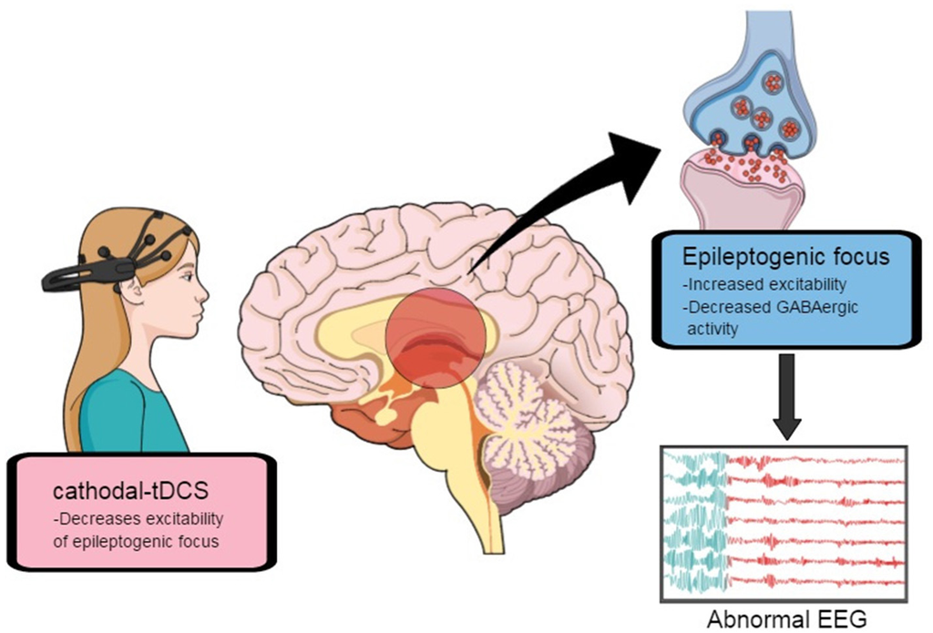

FIGURE 4 | Excitability in epileptogenic focus might be decreased by cathodal transcranial direct-current stimulation. Adapted from Fregni and Pascual-Leone (2007).

Regner et al.

Translating tDCS Studies in Epilepsy

neuronal activity, its long-term eﬀects seem to occur through

the modulation of synaptic transmission, causing LTD in the

thalamus-cingulate pathway. This process appears to be N-

methyl-D aspartate (NMDA) receptor- and duration-dependent

(Chang et al., 2015), thus c-tDCS seems to promote intracortical

inhibition. On the other hand, a-tDCS facilitates synaptic

plasticity mediated by a long-term potentiation (LTP)-like

mechanism, as well as previous studies presented that brief

seizures could induce LTP and mossy ﬁber sprouting in the

hippocampus; therefore, the mechanism of LTP formation might

be similar to the mechanism of epileptogenesis (Chang et al.,

2015; Rroji et al., 2015). Finally, the mechanisms underlying the

eﬀects of tDCS seem to be involved not only in local polarity-

related modiﬁcations of cortical excitability, but also in more

complex interhemispheric connections (Tatti et al., 2016).

CONCLUSIONS

Considering the data obtained in this review, we conclude

that tDCS should be considered a viable therapeutic option

in refractory epilepsy, particularly in patients who are unable

to undergo surgery. In general, animal studies used c-tDCS

montages, the stimulation appears to be bicephalic, due to the

animal’s skull size. At present, clinical studies involving c-tDCS

use ranging from 1 to 2 mA, and the cathode is placed over the

epileptic foci in majority. Cathodal tDCS appears to decrease

excitability through hyperpolarization associated to LTD-like

mechanisms. Moreover, because tDCS is simple to use, low

cost, and easily accessible, it is a good option in countries

with limited resources (Scorza and Brunoni, 2015; Zoghi et al.,

2016). Therefore, despite the intriguing possibility of modulating

neural networks, tDCS still requires a more in-depth analysis of

the most beneﬁcial protocols and elucidation of the underlying

mechanism of action. Thus, this non-invasive technique still

requires further sham-controlled, double-blind larger multi-

center studies, which may be justiﬁed for cost-eﬀectiveness and

surgery complication avoidance. Novel methods of real-time

assessment with EEG, and use of other neural markers, may

also help with understanding the clinical eﬀects of tDCS in

epilepsy (Faria et al., 2012; Leite et al., 2017). Although there

are several trials published in this ﬁeld, further evidence is

needed to understand the potential role of using tDCS to treat

epilepsy.

AUTHOR CONTRIBUTIONS

All authors participated in the design of the study and drafted

the manuscript. IT and PP participated in study coordination

and helped draft the manuscript. FF and DL helped ﬁnalize

the manuscript. GR, CdO, and RV have designed and prepared

the manuscript ﬁgures. All authors read and approved the ﬁnal

manuscript.

ACKNOWLEDGMENTS

The authors were supported by the Brazilian’s agencies: Conselho

Nacional de Desenvolvimento Cientíﬁco e Tecnológico (IT; PP),

Federal University of Rio Grande do Sul and Brazilian Federal

Agency for Support and Evaluation of Graduate Education—

CAPES/PNPD (CdO); CAPES Edital MD-PhD/2015 (DL). We

also want to thank the Engineering Division from the HCPA

for having developed the tDCS stimulator, MCT/FINEP—

COENG/2013.

REFERENCES

Accornero, N., Li Voti, P., La Riccia, M., and Gregori, B. (2007). Visual evoked

potentials modulation during direct current cortical polarization. Exp. Brain

Res. 178, 261–266. doi: 10.1007/s00221-006-0733-y

Andrade-Valença, L. P., Valença, M. M., Velasco, T. R., Carlotti, C. G., Assirati, J.

A., Galvis-Alonso, O. Y., et al. (2008). Mesial temporal lobe epilepsy: clinical

and neuropathologic ﬁndings of familial and sporadic forms. Epilepsia 49,

1046–1054. doi: 10.1111/j.1528-1167.2008.01551.x

Ardolino, G., Bossi, B., Barbieri, S., and Priori, A. (2005). Non-synaptic

mechanisms underlie the after-eﬀects of cathodal transcutaneous direct

current

stimulation

of

the

human

brain.

J.

Physiol.

568,

653–663.

doi: 10.1113/jphysiol.2005.088310

Assenza, G., Campana, C., Assenza, F., Pellegrino, G., Di Pino, G., Fabrizio,

E., et al. (2017). Cathodal transcranial direct current stimulation reduces

seizure frequency in adults with drug-resistant temporal lobe epilepsy: a sham

controlled study. Brain Stimul. 10, 333–335. doi: 10.1016/j.brs.2016.12.005

Assenza, G., Campana, C., Formica, D., Schena, E., Taﬀoni, F., Di Pino, G., et al.

(2014). Eﬃcacy of cathodal transcranial direct current stimulation in drug-

resistant epilepsy: a proof of principle. Conf. Proc. IEEE Eng. Med. Biol. Soc.

2014, 530–533. doi: 10.1109/EMBC.2014.6943645

Auvichayapat, N., Rotenberg, A., Gersner, R., Ngodklang, S., Tiamkao, S.,

Tassaneeyakul, W., et al. (2013). Transcranial direct current stimulation for

treatment of refractory childhood focal epilepsy. Brain Stimul. 6, 696–700.

doi: 10.1016/j.brs.2013.01.009

Auvichayapat, N., Sinsupan, K., Tunkamnerdthai, O., and Auvichayapat, P.

(2016). Transcranial direct current stimulation for treatment of childhood

pharmacoresistant lennox-gastaut syndrome: a pilot study. Front. Neurol. 7:66.

doi: 10.3389/fneur.2016.00066

Bikson, M., Grossman, P., Thomas, C., Zannou, A. L., Jiang, J., Adnan, T.,

et al. (2016). Safety of transcranial direct current stimulation: evidence

based update 2016. Brain Stimul. 9, 641–661. doi: 10.1016/j.brs.2016.

06.004

Chang, W. P., Lu, H. C., and Shyu, B. C. (2015). Treatment with direct-current

stimulation against cingulate seizure-like activity induced by 4-aminopyridine

and bicuculline in an in vitro mouse model. Exp. Neurol. 265, 180–192.

doi: 10.1016/j.expneurol.2015.02.002

Chindo, B. A., Ya,’U. J., Danjuma, N. M., Okhale, S. E., Gamaniel, K. S., and

Becker, A. (2014). Behavioral and anticonvulsant eﬀects of the standardized

extract of Ficus platyphylla stem bark. J. Ethnopharmacol. 154, 351–360.

doi: 10.1016/j.jep.2014.03.061

Covolan, L., and Mello, L. E. (2000). Temporal proﬁle of neuronal injury following

pilocarpine or kainic acid-induced status epilepticus. Epilepsy Res. 39, 133–152.

doi: 10.1016/S0920-1211(99)00119-9

D’Ambrosio,

R.,

and

Perucca,

E.

(2004).

Epilepsy

after

head

injury.

Curr.

Opin.

Neurol.

17,

731–735.

doi:

10.1097/00019052-200412000-

00014

Depaulis, A., and Hamelin, S. (2015). Animal models for mesiotemporal

lobe epilepsy: the end of a misunderstanding? Rev. Neurol. 171, 217–226.

doi: 10.1016/j.neurol.2015.01.558

Regner et al.

Translating tDCS Studies in Epilepsy

Dhamne, S. C., Ekstein, D., Zhuo, Z., Gersner, R., Zurakowski, D., Loddenkemper,

T., et al. (2015). Acute seizure suppression by transcranial direct current

stimulation in rats. Ann. Clin. Trans. Neurol. 2, 843–856. doi: 10.1002/acn3.226

Dhir, A., Naidu, O. S., and Kulkarni, S. K. (2005). Eﬀect of naproxen,

a

non-selective

cyclo-oxygenase

inhibitor,

on

pentylenetetrazol-

induced kindling in mice. Clin. Exp. Pharmacol. Physiol. 32, 579–584.

doi: 10.1111/j.1440-1681.2005.04233.x

Faria, P., Fregni, F., Sebastião, F., Dias, A. I., and Leal, A. (2012). Feasibility

of focal transcranial DC polarization with simultaneous EEG recording:

preliminary assessment in healthy subjects and human epilepsy. Epilepsy Behav.

25, 417–425. doi: 10.1016/j.yebeh.2012.06.027

Fertonani, A., Rosini, S., Cotelli, M., Rossini, P. M., and Miniussi, C. (2010).

Naming facilitation induced by transcranial direct current stimulation. Behav.

Brain Res. 208, 311–318. doi: 10.1016/j.bbr.2009.10.030

Fregni, F., and Pascual-Leone, A. (2007). Technology insight: noninvasive brain

stimulation in neurology-perspectives on the therapeutic potential of rTMS and

tDCS. Nat. Clin. Pract. Neurol. 3, 383–393. doi: 10.1038/ncpneuro0530

Fregni, F., Thome-Souza, S., Nitsche, M. A., Freedman, S. D., Valente, K.

D., and Pascual-Leone, A. (2006). A controlled clinical trial of cathodal

DC polarization in patients with refractory epilepsy. Epilepsia 47, 335–342.

doi: 10.1111/j.1528-1167.2006.00426.x

French, J. A. (2007). Refractory epilepsy: clinical overview. Epilepsia 48, 3–7.

doi: 10.1111/j.1528-1167.2007.00992.x

Gomez Palacio Schjetnan, A., Faraji, J., Metz, G. A., Tatsuno, M., and

Luczak, A. (2013). Transcranial direct current stimulation in stroke

rehabilitation: a review of recent advancements. Stroke Res. Treat. 2013:170256.

doi: 10.1155/2013/170256

Grippe, T. C., Brasil-Neto, J. P., Boechat-Barros, R., Cunha, N. S., and Oliveira, P.

L. (2015). Interruption of Epilepsia Partialis Continua by Transcranial Direct

Current Stimulation. Brain Stimul. 8, 1227–1228. doi: 10.1016/j.brs.2015.08.004

Gschwind, M., and van Mierlo, P. (2016). Diﬃculty of comparing the multiple

heterogeneous approaches: comment to transcranial direct current stimulation

in epilepsy. Brain Stimul. 9, 459–461. doi: 10.1016/j.brs.2016.03.003

Hayashi, Y., Hattori, Y., Asaki, H., Moriwaki, A., and Hori, Y. (1988). Eﬀects of

prolonged weak anodal direct current on electrocorticogram in awake rabbit.

Acta Med. Okayama 42, 293–296.

Henderson, V. C., Kimmelman, J., Fergusson, D., Grimshaw, J. M., and Hackam,

D. G. (2013). Threats to validity in the design and conduct of preclinical eﬃcacy

studies: a systematic review of guidelines for in vivo animal experiments. PLoS

Med. 10:e1001489. doi: 10.1371/journal.pmed.1001489

Higgins, J., and Green, S. (eds.). (2011). Cochrane Handbook for Systematic Reviews

of Interventions. Version 5.1.0. The Cochrane Collaboration.

Hooijmans, C. R., Rovers, M. M., de Vries, R. B., Leenaars, M., Ritskes-Hoitinga,

M., and Langendam, M. W. (2014). SYRCLE’s risk of bias tool for animal

studies. BMC Med. Res. Methodol. 14:43.doi: 10.1186/1471-2288-14-43

Jackson, M. P., Rahman, A., Lafon, B., Kronberg, G., Ling, D., Parra,

L.

C.,

et

al.

(2016).

Animal

models

of

transcranial

direct

current

stimulation: methods and mechanisms. Clin. Neurophysiol. 127, 3425–3454.

doi: 10.1016/j.clinph.2016.08.016

Kamida, T., Kong, S., Eshima, N., Abe, T., Fujiki, M., and Kobayashi, H. (2011).

Transcranial direct current stimulation decreases convulsions and spatial

memory deﬁcits following pilocarpine-induced status epilepticus in immature

rats. Behav. Brain Res. 217, 99–103. doi: 10.1016/j.bbr.2010.08.050

Kamida, T., Kong, S., Eshima, N., and Fujiki, M. (2013). Cathodal transcranial

direct current stimulation aﬀects seizures and cognition in fully amygdala-

kindled rats. Neurol. Res. 35, 602–607. doi: 10.1179/1743132813Y.0000000170

Kandratavicius,

L.,

Balista,

P.

A.,

Lopes-Aguiar,

C.,

Ruggiero,

R.

N.,

Umeoka, E. H., Garcia-Cairasco, N., et al. (2014). Animal models of

epilepsy: use and limitations. Neuropsychiatr. Dis. Treat. 10, 1693–1705.

doi: 10.2147/NDT.S50371

Lason, W., Chlebicka, M., and Rejdak, K. (2013). Research advances in basic

mechanisms of seizures and antiepileptic drug action. Pharmacol. Rep. 65,

787–801. doi: 10.1016/S1734-1140(13)71060-0

Lefaucheur, J. P. (2016). A comprehensive database of published tDCS clinical trials

(2005-2016). Neurophysiol. Clin. 46, 319–398. doi: 10.1016/j.neucli.2016.10.002

Leite,

J.,

Morales-Quezada,

L.,

Carvalho,

S.,

Thibaut,

A.,

Doruk,

D.,

Chen,

C.

F.,

et

al.

(2017).

Surface

EEG-transcranial

direct

current

stimulation (tDCS) closed-loop system. Int. J. Neural Syst. 27:1750026.

doi: 10.1142/S0129065717500265

Liebetanz, D., Fregni, F., Monte-Silva, K. K., Oliveira, M. B., Amâncio-dos-Santos,

A., Nitsche, M. A., et al. (2006a). After-eﬀects of transcranial direct current

stimulation (tDCS) on cortical spreading depression. Neurosci. Lett. 398, 85–90.

doi: 10.1016/j.neulet.2005.12.058

Liebetanz, D., Klinkerm, F., Hering, D., Koch, R., Nitsche, M. A., Potschka, H.,

et al. (2006b). Anticonvulsant eﬀects of transcranial direct-current stimulation

(tDCS) in the rat cortical ramp model of focal epilepsy. Epilepsia 47, 1216–1224.

doi: 10.1111/j.1528-1167.2006.00539.x

Loscher,

W.

(2002).

Current

status

and

future

directions

in

the

pharmacotherapy

of

epilepsy.

Trends

Pharmacol.

Sci.

23,

113–118.

doi: 10.1016/S0165-6147(00)01974-X

Löscher, W. (2011). Critical review of current animal models of seizures and

epilepsy used in the discovery and development of new antiepileptic drugs.

Seizure 20, 359–368. doi: 10.1016/j.seizure.2011.01.003

Loscher, W., and Schmidt, D. (2004). New horizons in the development of

antiepileptic drugs: the search for new targets. Epilepsy Res. 60, 77–159.

doi: 10.1016/j.eplepsyres.2004.06.004

McCormick,

D.

A.,

and

Contreras,

D.

(2001).

On

the

cellular

and

network bases of epileptic seizures. Annu. Rev. Physiol. 63, 815–846.

doi: 10.1146/annurev.physiol.63.1.815

Medeiros, L. F., de Souza, I. C., Vidor, L. P., de Souza, A., Deitos, A., Volz, M. S.,

et al. (2012). Neurobiological eﬀects of transcranial direct current stimulation:

a review. Front. Psychiatr. 3:110. doi: 10.3389/fpsyt.2012.00110

Nitsche, M. A., Cohen, L. G., Wassermann, E. M., Priori, A., Lang, N., Antal, A.,

et al. (2008). Transcranial direct current stimulation: state of the art. Brain

Stimul. 1, 206–223. doi: 10.1016/j.brs.2008.06.004

Nitsche, M. A., Liebetanz, D., Lang, N., Antal, A., Tergau, F., and Paulus, W. (2003).

Safety criteria for transcranial direct current stimulation (tDCS) in humans.

Clin. Neurophysiol. 114, 2220–2222. doi: 10.1016/S1388-2457(03)00235-9

Nitsche, M. A., and Paulus, W. (2009). Noninvasive brain stimulation protocols in

the treatment of epilepsy: current state and perspectives. Neurotherapeutics 6,

244–250. doi: 10.1016/j.nurt.2009.01.003

Pereira, L. S., Müller, V. T., da Mota Gomes, M., Rotenberg, A., and

Fregni, F. (2016). Safety of repetitive transcranial magnetic stimulation in

patients with epilepsy: a systematic review. Epilepsy Behav. 57, 167–176.

doi: 10.1016/j.yebeh.2016.01.015

Petrovski, S., Szoeke, C. E. I., Jones, N. C., Salzberg, M. R., Sheﬃeld, L. J.,

Huggins, R. M., et al. (2010). Neuropsychiatric symptomatology predicts

seizure recurrence in newly treated patients. Neurology 75, 1015–1021.

doi: 10.1212/WNL.0b013e3181f25b16

Raghavan, S., Eldabe, S., and Strachan, R. (2008). Novel trends in pain

management – Neuromodulation. Curr. Anaesth. Crit. Care 19, 344–348.

doi: 10.1016/j.cacc.2008.07.005

Rosen, A. C., Ramkumar, M., Nguyen, T., and Hoeft, F. (2009). Noninvasive

transcranial brain stimulation and pain. Curr. Pain Headache Rep. 13, 12–17.

doi: 10.1007/s11916-009-0004-2

Rroji, O., van Kuyck, K., Nuttin, B., and Wenderoth, N. (2015). Anodal

tDCS

over

the

primary

motor

cortex

facilitates

long-term

memory

formation reﬂecting use-dependent plasticity. PLoS ONE 10:e0127270.

doi: 10.1371/journal.pone.0127270

Ruscheweyh, R., Wilder-Smith, O., Drdla, R., Liu, X. G., and Sandkühler, J. (2011).

Long-term potentiation in spinal nociceptive pathways as a novel target for pain

therapy. Mol. Pain 7:20. doi: 10.1186/1744-8069-7-20

San-Juan, D., Calcáneo, Jde, D., González-Aragón, M. F., Maldonado, L. B.,

Avellán, A. M., Argumosa, E. V., et al. (2011). Transcranial direct current

stimulation in adolescent and adult Rasmussen’s encephalitis. Epilepsy Behav.

20, 126–131. doi: 10.1016/j.yebeh.2010.10.031

San-Juan, D., Espinoza López, D. A., Vázquez Gregorio, R., Trenado, C.,

Fernández-González

Aragón,

M.,

Morales-Quezada,

L.,

et

al.

(2017).

Transcranial direct current stimulation in mesial temporal lobe epilepsy and

Hippocampal Sclerosis. Brain Stimul. 10, 28–35. doi: 10.1016/j.brs.2016.08.013

San-Juan, D., Morales-Quezada, L., Orozco Garduño, A. J., Alonso-Vanegas,

M., González-Aragón, M. F., Espinoza López, D. A., et al. (2015).

Transcranial direct current stimulation in epilepsy. Brain Stimul. 8, 455–464.

doi: 10.1016/j.brs.2015.01.001

Regner et al.

Translating tDCS Studies in Epilepsy

Scorza, F. A., and Brunoni, A. R. (2015). Transcranial direct current stimulation

against sudden unexpected death in epilepsy: press that button again, please.

Brain Stimul. 8, 839–840. doi: 10.1016/j.brs.2015.04.006

Sloviter,

R.

S.

(2008).

Hippocampal

epileptogenesis

in

animal

models

of

mesial

temporal

lobe

epilepsy

with

hippocampal

sclerosis:

the

importance of the “latent period” and other concepts. Epilepsia 49, 85–92.

doi: 10.1111/j.1528-1167.2008.01931.x

Tatti, E., Rossi, S., Innocenti, I., Rossi, A., and Santarnecchi, E. (2016). Non-

invasive brain stimulation of the aging brain: state of the art and future

perspectives. Ageing Res. Rev. 29, 66–89. doi: 10.1016/j.arr.2016.05.006

Tekturk, P., Erdogan, E. T., Kurt, A., Kocagoncu, E., Kucuk, Z., Kinay, D.,

et al. (2016a). Transcranial direct current stimulation improves seizure

control in patients with Rasmussen encephalitis. Epileptic Disord. 18, 58–66.

doi: 10.1684/epd.2016.0796

Tekturk, P., Erdogan, E. T., Kurt, A., Vanli-Yavuz, E. N., Ekizoglu, E.,

Kocagoncu, E., et al. (2016b). The eﬀect of transcranial direct current

stimulation on seizure frequency of patients with mesial temporal lobe

epilepsy with hippocampal sclerosis. Clin. Neurol. Neurosurg. 149, 27–32.

doi: 10.1016/j.clineuro.2016.07.014

van Elst, L. T., Woermann, F. G., Lemieux, L., Thompson, P. J., and

Trimble, M. R. (2000). Aﬀective aggression in patients with temporal lobe

epilepsy: a quantitative MRI study of the amygdale. Brain 123, 234–243.

doi: 10.1093/brain/123.2.234

Woods, A. J., Antal, A., Bikson, M., Boggio, P. S., Brunoni, A. R., Celnik, P., et al.

(2016). A technical guide to tDCS, and related non-invasive brain stimulation

tools.

Clin.

Neurophysiol.

127,

1031–1048.

doi:

10.1016/j.clinph.2015.

11.012

Yook, S. W., Park, S. H., Seo, J. H., Kim, S. J., and Ko, M. H. (2011).

Suppression of seizure by cathodal transcranial direct current stimulation

in an epileptic patient - a case report. Ann. Rehabil. Med. 35, 579–582.

doi: 10.5535/arm.2011.35.4.579

Zhang, Z., Liao, W., Xu, Q., Wei, W., Zhou, H. J., Sun, K., et al. (2017).

Hippocampus-associated causal network of structural covariance measuring

structural damage progression in temporal lobe epilepsy. Hum. Brain Mapp.

38, 753–766. doi: 10.1002/hbm.23415

Zobeiri, M., and van Luijtelaar, G. (2013). Noninvasive transcranial direct

current stimulation in a genetic absence model. Epilepsy Behav. 26, 42–50.

doi: 10.1016/j.yebeh.2012.10.018

Zoghi, M., O’Brien, T. J., Kwan, P., Cook, M. J., Galea, M., and Jaberzadeh, S.

(2016). The eﬀects of cathodal transcranial direct current stimulation in a

patient with drug-resistant temporal lobe epilepsy (case study). Brain Stimul.

9, 790–792. doi: 10.1016/j.brs.2016.05.011

**Conﬂict of Interest Statement:** The authors declare that the research was

conducted in the absence of any commercial or ﬁnancial relationships that could

be construed as a potential conﬂict of interest.

Copyright © 2018 Regner, Pereira, Leﬀa, de Oliveira, Vercelino, Fregni and Torres.

This is an open-access article distributed under the terms of the Creative Commons

Attribution License (CC BY). The use, distribution or reproduction in other forums

is permitted, provided the original author(s) and the copyright owner are credited

and that the original publication in this journal is cited, in accordance with accepted

academic practice. No use, distribution or reproduction is permitted which does not

comply with these terms.